# Loan Default Prediction for Financial Risk Management

## Principal Component Analysis:

The images and R code illustrate a Principal Component Analysis (PCA) performed on a preprocessed dataset. Categorical variables were converted to numeric using one-hot encoding, missing values were handled, and data was standardized before applying PCA. The Scree Plot shows the variance explained by each component, helping determine the optimal number of principal components. The scatter plot of the first two principal components visualizes the data distribution, revealing potential clusters or patterns. This analysis helps reduce dimensionality while preserving key information in the dataset.

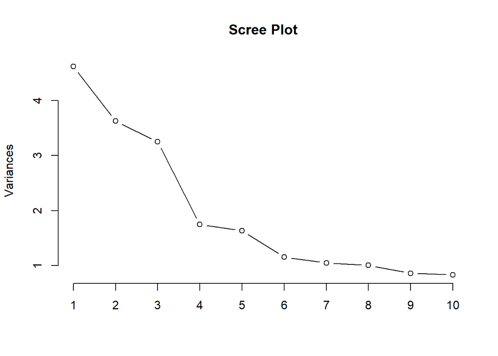

```r
# Step 1: Convert categorical variables to numeric using one-hot encoding
df_numeric <- df %>%
 mutate(across(c(Gender, Marital_status, Emp_status), as.factor)) %>%  # Convert to factors
   dummyVars(~ ., data = .) %>%
  predict(newdata = df) %>%
   as.data.frame()

 # Step 2: Select only numeric features
 numeric_data <- df_numeric %>% select_if(is.numeric)

 # Step 3: Handle missing and infinite values
 numeric_data[is.na(numeric_data)] <- 0   # Replace NAs with 0 (or use median imputation)

 constant_cols <- apply(numeric_data, 2, function(col) var(col, na.rm = TRUE) == 0)
numeric_data <- numeric_data[, !constant_cols]


 # Step 4: Standardize the data (only after handling missing values)
 scaled_data <- scale(numeric_data)

 # Step 5: Perform PCA
 pca_result <- prcomp(scaled_data, center = TRUE, scale = TRUE)

 # Step 6: Scree Plot (to decide number of components to keep)
 screeplot(pca_result, type = "lines", main = "Scree Plot")
```

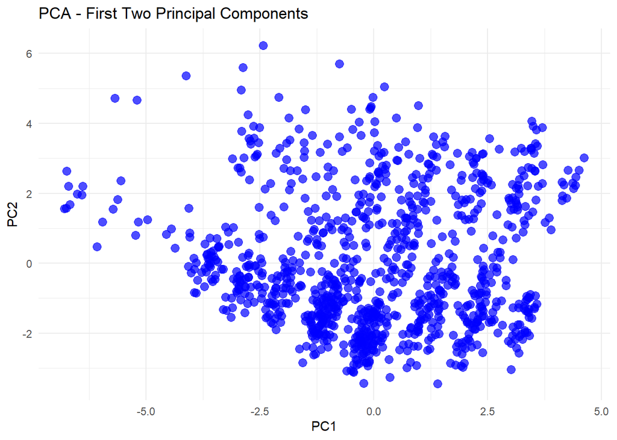

```r
 # Step 7: Biplot (PCA visualization)
# biplot(pca_result, scale = 0)

 # Step 8: Scatter plot of first two principal components
 pca_df <- as.data.frame(pca_result$x)
 ggplot(pca_df, aes(x = PC1, y = PC2)) +
   geom_point(size = 3, alpha = 0.7, color = "blue") +
 labs(title = "PCA - First Two Principal Components") +
   theme_minimal()
```

```r
variance_explained <- summary(pca_result)$importance[2, ]  # Extract proportion of variance explained
print(variance_explained)
```

```
    PC1     PC2     PC3     PC4     PC5     PC6     PC7     PC8     PC9    PC10
0.20084 0.15781 0.14133 0.07609 0.07105 0.05022 0.04544 0.04362 0.03742 0.03606
   PC11    PC12    PC13    PC14    PC15    PC16    PC17    PC18    PC19    PC20
0.03455 0.03249 0.02725 0.02153 0.01750 0.00460 0.00187 0.00034 0.00000 0.00000
   PC21    PC22    PC23
0.00000 0.00000 0.00000
```